# 18.Strain Gauges

## What Is It?

At it's simplest, a strain gauge is a resistor consisting of a flexible film material that supports a metallic foil pattern. A strain gauge is a device used to measure the strain of a material. Remember, mechanical strain is the ratio of the elongation (or contraction) of a material to the material's original length. It is typically represented by the Greek letter epsilon $ \epsilon $ or $ \varepsilon $. It is expressed mathematically as

$$ \varepsilon = \frac{\Delta \ell}{\ell} $$

where $ \ell $ is the original length and $ \Delta \ell $ is the change in length of the material. Shown below in Figure 1 is a depiction of a strain gauge.

Figure 1: Strain Gauge

[figure not shown]

The strain-sensitive pattern typically consists of a metallic material arranged in an alternating zig-zag pattern. Numerous patters may be used depending on the use case of the strain gauge. Shown below in Figure 2 are some different designs.

Figure 2: Strain Gauge Patterns

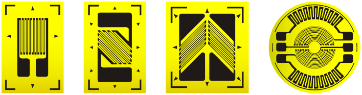

At the ends of these pattern are terminals which are sometimes called pads. The pads are the location of where wire extension leads will be solder.

## How Does It Work?

The strain gauge is first glued on to a member that experiences strain. In industry, there are very particular ways in which the strain gauge must be glued onto the member. The method used is to ensure accuracy in the strain measurement. Most methods involve some type of [cyanoacrylate](https://en.wikipedia.org/wiki/Cyanoacrylate). Cyanoacrylates are a family of adhesives. Super glue is probably the most commonly known cyanoacrylate. For this course's purposes, super glue will be adequate in the adhesion of the strain gauge to the member experiencing strain. The strain gauge's adhesion ensures that the strain gauge also experiences whatever strain is experienced by the member. The metallic material of the strain is produced to a highly accurate thickness and width. Accurate production allows for a consistent cross-section. It is well known that a material's resistance is determined by the material's length $ L $, cross-section $ A $, and resistivity $ \rho $. Resistivity is a material property that is [tabulated](https://www.engineeringtoolbox.com/resistivity-conductivity-d_418.html) for various materials. If these three quantities are known, then the resistance of a specimen is given as

$$ R = \rho \frac{L}{A} $$

In the case of a strain gauge, the length, cross-sectional area, and resistivity are well known; thus, the strain gauge's resistance may be determined. When the strain gauge is not experiencing strain, the resistance of the strain gauge is known as the nominal resistance $ R_o $. A widespread nominal resistance $ R_o $ is $ 120 \Omega $, although practically any resistance value may be constructed. Now let's say the member experiences tension where the strain gauge is located. A member in tension is depicted below in Figure 3.

Figure 3: Strain Gauge In Tension

[figure not shown]

The strain gauge is stretched in tension, and the zig-zag pattern lines elongate while the cross-sectional area narrows. The tension produces an increase in resistance of the strain gauge. This change is denoted as $ \Delta R $. A member in compression may also be studied. A member in compression is shown below in Figure 4.

Figure 4: Strain Gauge In Compression

[figure not shown]

In compression, the strain gauge is compressed, and the zig-zag pattern lines shorten while the cross-sectional area thickens. The compression produces a decrease in resistance of the strain gauge. These changes in resistance are what will be measured. The changes in resistance $ \Delta R $ is related to the strain experienced by the strain gauge by the expression shown below.

$$ \varepsilon = \frac{\frac{\Delta R}{R_o}}{GF} $$

where $ \Delta R $ is the change in resistance of the strain gauge, $ R_o $ is the nominal resistance of the strain gauge, and $ GF $ is the strain gauge's gauge factor. The gauge factor $ GF $ is a proportional constant that is decided in the strain gauge design phase. Although any gauge factor $ GF $ may be used, a widespread gauge factor $ GF $ is approximately $ 2.1 $. The gauge factor may be found from the strain gauge manufacturer's datasheet. The gauge factor for the strain gauge in your kit is $ 2.1 $. While strain $ \varepsilon $ is a significant quantity to know about a member, stress $ \sigma $ is typically the desired quantity. Recall that uniaxial stress $ \sigma $ is given by

$$ \sigma = E \varepsilon $$

where $ E $ is the [modulus of elasticity](https://en.wikipedia.org/wiki/Elastic_modulus) or Young's modulus. The modulus of elasticity is a tabulated property for a material. The change in resistance $ \Delta R $ of a strain gauge will often be very small for even large strain situations. For example, a strain of $ 0.05 \frac{in}{in} $ would only produce a change of resistance of $ 12.6 \Omega $. Typically a voltage divider circuit is implemented to measure resistance as a change of voltage, but in this case, a voltage divider circuit is not well suited. With such a small relative change, a voltage divider circuit will not be sensitive enough. It is also susceptible to thermal effects. Not to mention the voltage divider circuit has a zero offset due to the bias resistor. To overcome this limitation, a [Wheatstone bridge](https://en.wikipedia.org/wiki/Wheatstone_bridge) circuit is often used.

## Wheatstone Bridge

A Wheatstone bridge circuit is depicted below in Figure 5.

Figure 5: Wheatstone Bridge Circuit

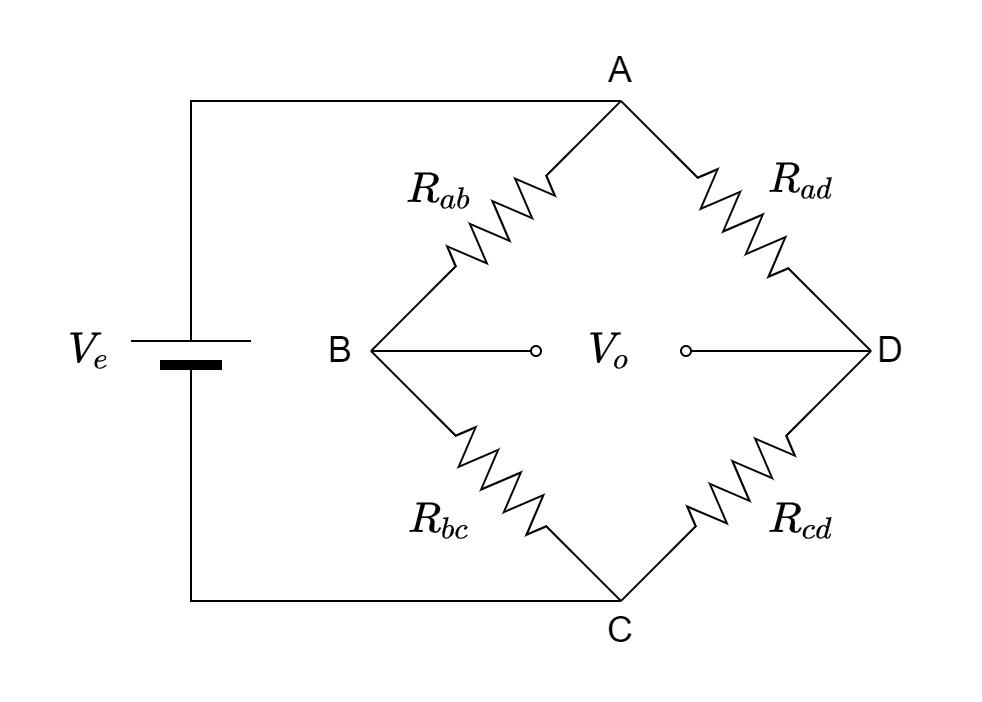

The circuit looks complicated at first glance, but it may readily be understood if taken piece by piece. First, the voltage source powering the circuit is known as the excitation voltage $ V_e $. This excitation voltage is connected to the nodes $ A $ and $ C $. The output of the circuit is the voltage output $ V_o $. This voltage is connected to the nodes $ B $ and $ D $. Between the nodes $ A $, $ B $, $ C $, and $ D $ are resistors $ R_{ab} $, $ R_{bc} $, $ R_{cd} $, and $ R_{ad} $. If nodes $ A $ and $ C $ are expanded, it may be seen that the Wheatstone bridge circuit is simply two voltage divider circuits in parallel. This new configuration is shown below in Figure 6.

Figure 6: Wheatstone Bridge Circuit Alternate View

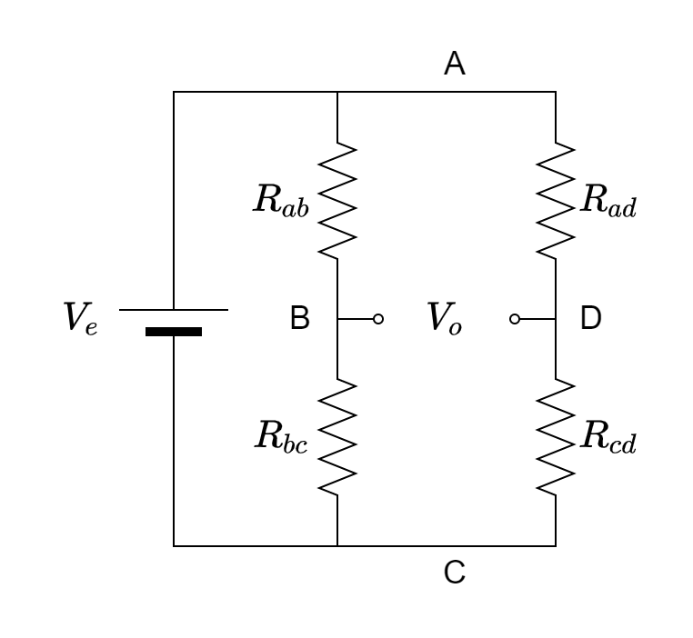

The current through the left voltage divider circuit $ I_{abc} $ is given by

$$ I_{abc} = \frac{V_e}{R_{ab} + R_{bc}} $$

The voltage at node $ B $ may then be found by

$$ V_b = I_{abc} R_{bc} = \frac{V_e R_{bc}}{R_{ab} + R_{bc}} $$

A similar process may be taken to find the voltage at node $ D $. The current through the right voltage divider circuit $ I_{adc} $ is given by

$$ I_{adc} = \frac{V_e}{R_{ad} + R_{cd}} $$

The voltage at node $ D $ may then be found by

$$ V_d = I_{adc} R_{cd} = \frac{V_e R_{cd}}{R_{ad} + R_{cd}} $$

The output voltage $ V_o $ is then

$$ V_o = V_d - V_b = \frac{V_e R_{cd}}{R_{ad} + R_{cd}} - \frac{V_e R_{bc}}{R_{ab} + R_{bc}} = V_e \frac{R_{ab}R_{cd} - R_{bc}R_{ad}}{\left(R_{ad} + R_{cd}\right)\left(R_{ab} + R_{bc}\right)} $$

The expression above is particularly useful. It shows the output voltage as it is related to the resistances and excitation voltage. What would the output voltage be if all the resistances where equal (i.e. $ R_{ab} = R_{bc} = R_{cd} = R_{ad} $ )? The output voltage $ V_o $, in this case, would be $ 0 V $. This particular state may readily be seen by evaluating the numerator of the expression. This state is known as a balanced Wheatstone bridge circuit. A balanced Wheatstone bridge is one where the output voltage $ V_o $ is $ 0 V $. An imbalanced Wheatstone bridge is one where the output voltage $ V_o $ is not zero. This state occurs when one resistor is not equal to the other equal valued resistors. An imbalance may occur in one of two ways. The first way, which is typically not desired, is due to differences in the rated value of a resistor to its actual value. It is commonly known that a resistor is rarely the exact value indicated by the color code on the resistor. This difference will produce an imbalance in the Wheatstone bridge circuit. This type of imbalance may be overcome by replacing one of the resistors in the Wheatstone bridge circuit with a [potentiometer](https://en.wikipedia.org/wiki/Potentiometer). A potentiometer is a special type of resistor that its value may be precisely changed by using a knob or slider. Sometimes potentiometers are known as a variable resistor or rheostat. Replacing the resistor $ R_{ad} $ in the Wheatstone bridge circuit is shown below.

Figure 6: Wheatstone Bridge Circuit with potentiometer

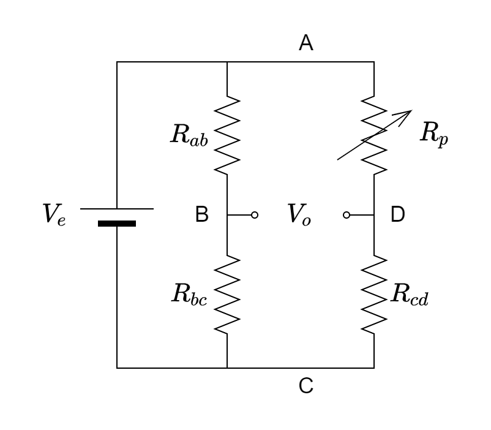

The resistance of the potentiometer $ R_p $ may be adjusted to balance an imbalanced Wheatstone bridge circuit. Balancing the circuit is typically done when the circuit is first constructed. The second type of imbalance results from a change in resistance value of one or more of the resistors. Ideally, only one resistor value would change at a time. In this case, the imbalance may be related to the change in resistance $ \Delta R $ of that particular resistor. For the sake of discussion, let's say that the resistor $ R_{cd} $ experiences a change in resistance $ \Delta R $ from its nominal value of $ R_o $. The total resistance of the resistor $ R_{cd} $ may be written as

$$ R_{cd} = R_o + \Delta R $$

The output voltage $ V_o $ may then be written as

$$ V_o = V_e \frac{R_{ab}\left(R_o + \Delta R\right)- R_{bc}R_p}{\left(R_p + R_o + \Delta R\right)\left(R_{ab} + R_{bc}\right)} $$

Solving for the change in resistance $ \Delta R $ yields

$$ \Delta R = \frac{V_e \left( R_{ab}R_o - R_{bc}R_p \right) - V_o \left( R_{ab} + R_{bc} \right)\left( R_p + R_o \right)}{V_o \left( R_{ab} + R_{bc} \right) - V_e R_{ab}} $$

Hopefully, by now, it is apparent where this line of thought is going. A strain gauge may replace the resistor $ R_{cd} $ with a resistance of $ R_g $. Replacing $ R_{cd} $ with $ R_g $ is shown below in Figure 7.

Figure 7: Wheatstone Bridge Circuit with strain gauge

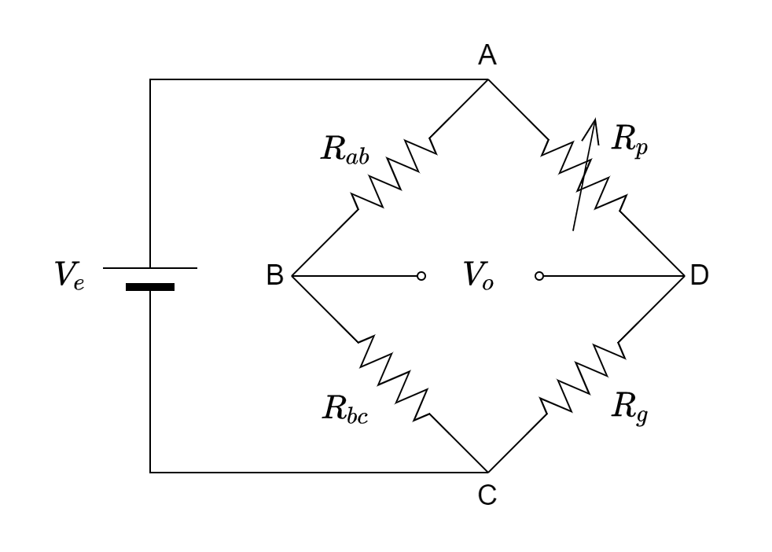

This type of Wheatstone bridge configuration is known as a quarter-bridge. That is because one-quarter of the bridge is used to measure a change in some quantity. There are also half-bridge and full-bridge configurations that are sometimes implemented depending on the particular application. Examples of these may be found [here](https://www.allaboutcircuits.com/textbook/direct-current/chpt-9/strain-gauges/).

## Load Cells

While the application of a strain gauge is widely used in industry, what is more commonly seen is the use of a load cell. A load cell is a device used to measure force. They implement a strain gauge (or multiple strain gauges) to accomplish this goal. They come in a variety of configurations and shapes. Some of the more common types are listed below.

- S Beam

[figure not shown]

This type of load cell is often used to measure tensile loads. There are typically four different strain gauges in the load cell's center section in a full-bridge configuration.

- Cantilever Beam

[figure not shown]

This type of load cell is often used in small digital scales like a scale used in the kitchen for cooking. Again, the middle section of the load cell is where the strain gauges are housed.

- Button

[figure not shown]

This type of load cell is used in measuring compressive load. A point load is applied to the small raised portion in the center of the load cell.

- 3-wire sensor

[figure not shown]

This type is probably the simplest type of load cell available. This type of load cell is commonly found in digital bathroom and postage scales. Sometimes this type of load cell is known as a load sensor. It is a type of cantilever beam load that only has one strain gauge. The two outer legs shown in the picture above are the base, and the center leg is the cantilever beam portion. The load is applied to this middle leg to measure compressive loads. While the wire colors are often different, the 3-wire load cell's basic configuration is shown below in Figure 8.

Figure 8: 3-Wire Load Cell Schematic

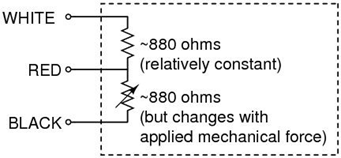

Since the wire colors often are different, a multimeter must be used to determine the particular sections of the circuit. It is quite common to utilize multiple 3-wire load cells to create a half-bridge Wheatstone bridge circuit. This configuration is what digital bathroom and postage scales typically do. The half-bridge configuration is shown below in Figure 9.

Figure 9: 3-Wire Load Cell Wheatstone Bridge Configuration

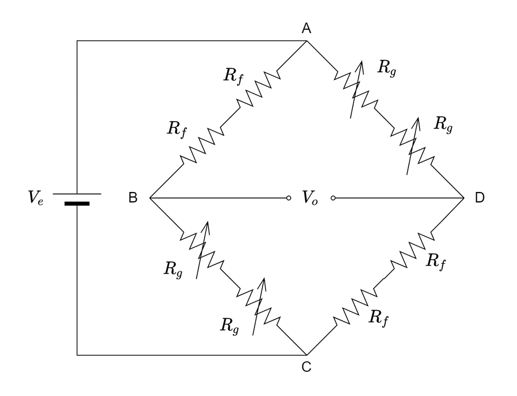

where $ R_g $ is the strain gauge portion of the 3-wire load cell, and $ R_f $ is the constant or fixed portion of the 3-wire load cell.